# Avaliação Continuada - Aula 3

### Base de Dados - Turma A

Os exercícios de avaliação continuada da **Turma A** serão realizados com a base de dados de corridas de taxi em Nova York, chamada de `taxis`. Essa é uma base de dados que é disponibilizada como dados de exemplo pela própria biblioteca `seaborn`, por meio da função `load_dataset`. Execute a célula a seguir para importar as bibliotecas de que vamos precisar e criar a variável `taxis` com nossa base de dados.

```python
# Importando a biblioteca seaborn
import seaborn as sns

# Carregando a base de dados 'taxis'
taxis = sns.load_dataset("taxis")

taxis.head(5)
```

|  | pickup | dropoff | passengers | distance | fare | tip | tolls | total | color | payment | pickup_zone | dropoff_zone | pickup_borough | dropoff_borough |
| --- | --- | --- | --- | --- | --- | --- | --- | --- | --- | --- | --- | --- | --- | --- |
| 0 | 2019-03-23 20:21:09 | 2019-03-23 20:27:24 | 1 | 1.60 | 7.0 | 2.15 | 0.0 | 12.95 | yellow | credit card | Lenox Hill West | UN/Turtle Bay South | Manhattan | Manhattan |
| 1 | 2019-03-04 16:11:55 | 2019-03-04 16:19:00 | 1 | 0.79 | 5.0 | 0.00 | 0.0 | 9.30 | yellow | cash | Upper West Side South | Upper West Side South | Manhattan | Manhattan |
| 2 | 2019-03-27 17:53:01 | 2019-03-27 18:00:25 | 1 | 1.37 | 7.5 | 2.36 | 0.0 | 14.16 | yellow | credit card | Alphabet City | West Village | Manhattan | Manhattan |
| 3 | 2019-03-10 01:23:59 | 2019-03-10 01:49:51 | 1 | 7.70 | 27.0 | 6.15 | 0.0 | 36.95 | yellow | credit card | Hudson Sq | Yorkville West | Manhattan | Manhattan |
| 4 | 2019-03-30 13:27:42 | 2019-03-30 13:37:14 | 3 | 2.16 | 9.0 | 1.10 | 0.0 | 13.40 | yellow | credit card | Midtown East | Yorkville West | Manhattan | Manhattan |

### Sobre os dados

A base `taxis` contém informações sobre 6.433 corridas de taxi (unidade de observação) de Nova Iorque, ocorridas em março de 2019. A base contém 14 variáveis (colunas), incluindo a data e horário de início e de fim de cada corrida, o número de passageiros, a distância em milhas percorrida, o preço da viagem, a zona e o bairro de embarque e de destino, entre outras informações.

Queremos verificar se a gorjeta média varia de acordo com o bairro de origem da corrida.

### Exercício de hoje

Escolha também uma cor para seu gráfico, diferente da cor padrão. Consulte a lista de cores nomeadas abaixo:

[figure not shown]

Após escrever a linha de código de sua resposta, execute a célula para mostrar o gráfico a partir da base `taxis`.

**Importante: antes de executar o código da sua resposta, não deixe de executar a célula de código que está no início deste caderno, que importa as bibliotecas e carrega os dados.**

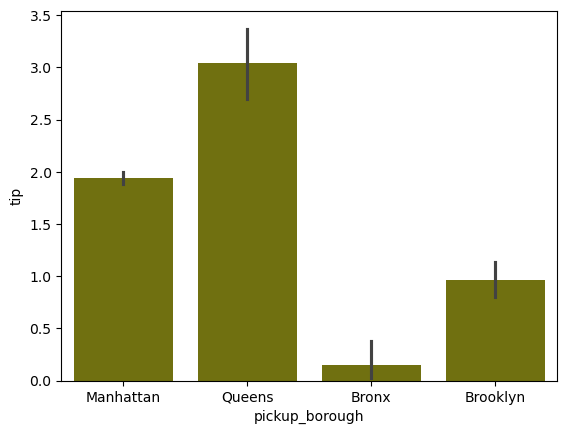

```python
## Escreva sua resposta abaixo e execute a célula para gerar o gráfico
sns.barplot(
    x="pickup_borough",
    y="tip",
    color="olive", # aqui poderia ser qualquer outra cor...
    data=taxis
)
```

# Parte 2

Copie o código do gráfico anterior.

Agora você deve remover a barra de erro do gráfico, que é exibida por padrão. Para isso, utilize o argumento `errorbar` com o valor `None`.

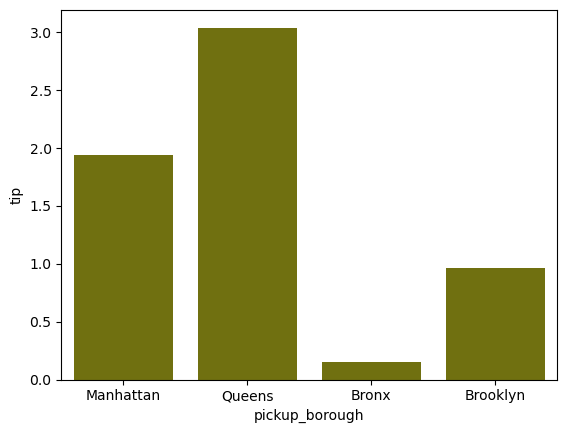

```python
sns.barplot(
    x="pickup_borough",
    y="tip",
    color="olive", # aqui poderia ser qualquer outra cor...
    errorbar=None,
    data=taxis
)
```